# Презентация по выполнению лабораторной работы №6

Операционные системы

Марцев Аркадий Алексеевич

РУДН

# Информация

## Докладчик

- Марцев Аркадий Алексеевич
- Студент
- Российский университет дружбы народов
- 1132239100@pfur.ru
- https://aamarcev.github.io/ru/

# Тема презентации

Основы интерфейса взаимодействия пользователя с системой Unix на уровне командной строки.

# Актуальность

- В рабочей среде в IT взаимодействие с ОС Linux на продвинутом уровне, часто, одно из основных требований.
- Для выполнения дальнейшей работы на курсе “Архитектура компьютеров и операционные системы”, нам нужно будет использовать те знания которые мы получим в ходе этой работы.
- Для ознакомления и взаимодействия с ОС на базе ядра Unix важно уметь пользоваться терминалом.

# Задание

1. Найти полное имя домашней директории.
2. Выполнить действия с командой ls.
3. Выполнить действия с командой mkdir, rmdir, rm.
4. Получить мануалы по использованию команд с помощью команды man.
5. Используя полученную информацию использовать раннее использованные команды со специальным ключом.

# Полное имя домашней директории

Для нахождения полного имени домашней директории пользуемся командой pwd.

# Действия с командой ls

При помощи команды ls мы можем выводить на экран содержимое директории, в которой находится пользователь.

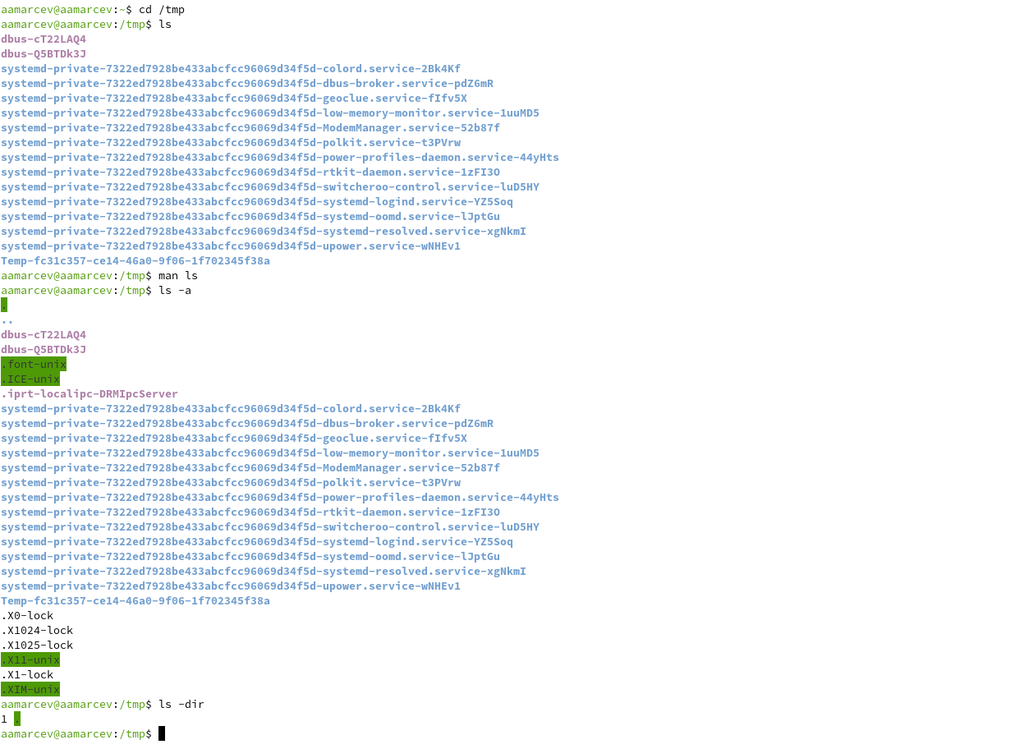

ls

# Ключи команды ls

Также при помощи ключей к командам мы можем использовать их дополнительные функции, так на представленном слайде при помощи ключа -alF мы выводим полное содержимое директории с дополнительной информацией о каждом элементе.

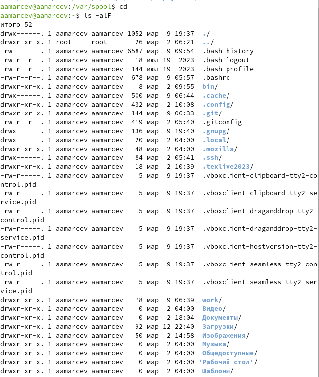

Вывод владельца каталогов

# mkdir

Команда mkdir нужна для создания новых директорий. С её помощью создаем директорию newdir а в ней поддиректорию morefun.

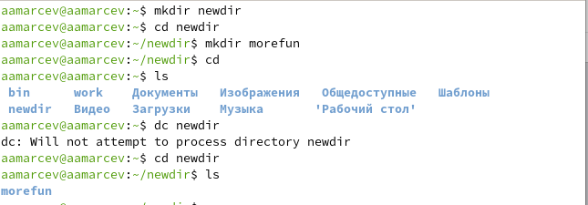

Создание директорий

# rmdir и rm

rmdir и rm используются для удаления пустых директорий и удаления любых элементов соответственно. В данном случае используется ключ рекурсивного удаления -r так как newdir не пустая директория.

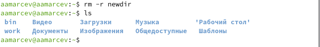

Удаление newdir

# Получение мануалов при помощи команды man

Команда man позволяет нам получить мануал к любой другой команде, в котором будет обьясняться как используется команды и какие ключи у неё есть. Так в лабораторной мы получили мануалы для команд cd, pwd mkdir, rmdir и rm.

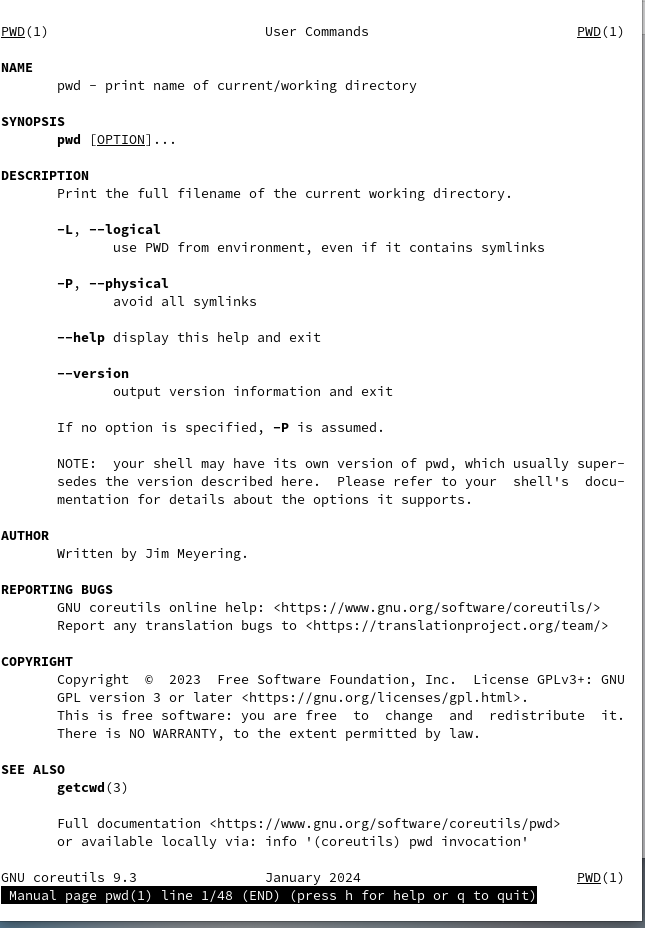

pwd

# Использование команд со специальным ключом

Получив список ключей к некоторым командам мы можем модифицировать их и использовать их особые свойства. Например в данном случае мы используем команду mkdir -p для создания директории и поддиректории в ней одновременно.

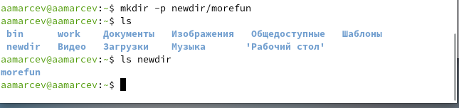

mkdir -p

# Итог и выводы

В ходе этой лабораторной работы мы научились взаимодействовать с файловой системой Linux при помощи терминала.